# Bayesian analysis with brms

The `marginaleffects` package offers convenience functions to compute and display predictions, contrasts, and marginal effects from bayesian models estimated by the `brms` package. To compute these quantities, `marginaleffects` relies on workshorse functions from the `brms` package to draw from the posterior distribution. The type of draws used is controlled by using the `type` argument of the `predictions` or `marginaleffects` functions:

- `type = "response"`: Compute posterior draws of the expected value using the `brms::posterior_epred` function.
- `type = "link"`: Compute posterior draws of the linear predictor using the `brms::posterior_linpred` function.
- `type = "prediction"`: Compute posterior draws of the posterior predictive distribution using the `brms::posterior_predict` function.

The `predictions` and `marginaleffects` functions can also pass additional arguments to the `brms` prediction functions via the `...` ellipsis. For example, if `mod` is a mixed-effects model, then this command will compute 10 draws from the posterior predictive distribution, while ignoring all group-level effects:

```r
predictions(mod, type = "prediction", ndraws = 10, re_formula = NA)
```

See the `brms` documentation for a list of available arguments:

```r
?brms::posterior_epred
?brms::posterior_linpred
?brms::posterior_predict
```

# Logistic regression with multiplicative interactions

Load libraries and download data on passengers of the Titanic from [the Rdatasets archive:](https://vincentarelbundock.github.io/Rdatasets/)

```r
library(marginaleffects)
library(brms)
library(ggplot2)
library(ggdist)
library(magrittr)

dat <- read.csv("https://vincentarelbundock.github.io/Rdatasets/csv/carData/TitanicSurvival.csv")
dat$survived <- ifelse(dat$survived == "yes", 1, 0)
dat$woman <- ifelse(dat$sex == "female", 1, 0)
```

Fit a logit model with a multiplicative interaction:

```r
mod <- brm(survived ~ woman * age + passengerClass,
           family = bernoulli(link = "logit"),
           data = dat)
```

## Adjusted predictions

We can compute [adjusted predicted values](https://vincentarelbundock.github.io/marginaleffects/articles/predictions.html) of the outcome variable (i.e., probability of survival aboard the Titanic) using the `predictions` function. By default, this function calculates predictions for each row of the dataset:

```r
pred <- predictions(mod)
head(pred)
```

```
#>   rowid     type predicted survived woman     age passengerClass  conf.low conf.high
#> 1     1 response 0.9363293        1     1 29.0000            1st 0.9098216 0.9611878
#> 2     2 response 0.8473119        1     0  0.9167            1st 0.7602898 0.9255607
#> 3     3 response 0.9421204        0     1  2.0000            1st 0.8972346 0.9729983
#> 4     4 response 0.5129703        0     0 30.0000            1st 0.4317595 0.5960417
#> 5     5 response 0.9370423        0     1 25.0000            1st 0.9088370 0.9609094
#> 6     6 response 0.2731266        1     0 48.0000            1st 0.1997047 0.3484897
```

To visualize the relationship between the outcome and one of the regressors, we can plot conditional adjusted predictions with the `plot_cap` function:

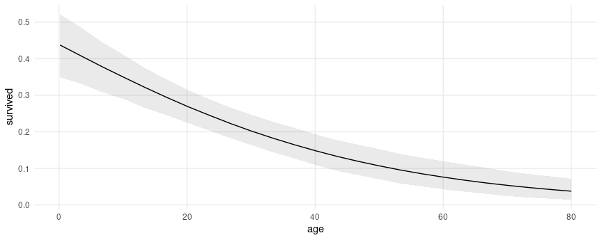

```r
plot_cap(mod, condition = "age")
```

Compute adjusted predictions for some user-specified values of the regressors, using the `newdata` argument and the `datagrid` function:

```r
pred <- predictions(mod,
                    newdata = datagrid(woman = 0:1,
                                       passengerClass = c("1st", "2nd", "3rd")))
pred
```

```
#>   rowid     type  predicted      age woman passengerClass   conf.low conf.high
#> 1     1 response 0.51472830 29.88113     0            1st 0.43368752 0.5986352
#> 2     2 response 0.93614415 29.88113     1            1st 0.90930611 0.9605184
#> 3     3 response 0.20271297 29.88113     0            2nd 0.15011114 0.2585327
#> 4     4 response 0.77885268 29.88113     1            2nd 0.71264810 0.8359897
#> 5     5 response 0.08758891 29.88113     0            3rd 0.06560364 0.1148385
#> 6     6 response 0.57199879 29.88113     1            3rd 0.49642230 0.6461308
```

The `posteriordraws` function samples from the posterior distribution of the model, and produces a data frame with `drawid` and `draw` columns.

```r
pred <- posteriordraws(pred)
head(pred)
```

```
#>   rowid     type drawid      draw      age woman passengerClass
#> 1     1 response      1 0.5163038 29.88113     0            1st
#> 2     1 response      2 0.5340073 29.88113     0            1st
#> 3     1 response      3 0.5107874 29.88113     0            1st
#> 4     1 response      4 0.5086535 29.88113     0            1st
#> 5     1 response      5 0.5982841 29.88113     0            1st
#> 6     1 response      6 0.5252051 29.88113     0            1st
```

This “long” format makes it easy to plots results:

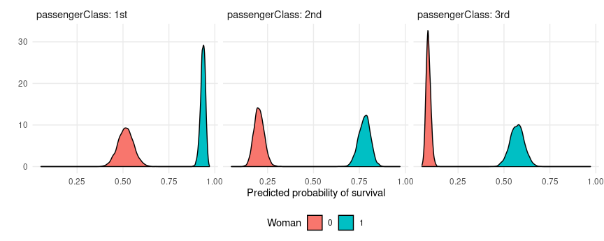

```r
ggplot(pred, aes(x = draw, fill = factor(woman))) +
    geom_density() +
    facet_grid(~ passengerClass, labeller = label_both) +
    labs(x = "Predicted probability of survival", y = "", fill = "Woman")
```

## Marginal effects

Use `marginaleffects()` to [compute marginal effects (slopes of the regression equation)](https://vincentarelbundock.github.io/marginaleffects/articles/mfx.html) for each row of the dataset, and use `summary()` to compute “Average Marginal Effects”, that is, the average of all observation-level marginal effects:

```r
mfx <- marginaleffects(mod)
summary(mfx)
```

```
#> Average marginal effects
#>             Term  Contrast    Effect     2.5 %    97.5 %
#> 1          woman     dY/dX  0.366002  0.338048  0.393182
#> 2            age     dY/dX -0.005239 -0.007038 -0.003495
#> 3 passengerClass 2nd - 1st -0.236254 -0.306317 -0.166685
#> 4 passengerClass 3rd - 1st -0.387400 -0.454317 -0.321181
#>
#> Model type:  brmsfit
#> Prediction type:  response
```

Compute marginal effects with some regressors fixed at user-specified values, and other regressors held at their means:

```r
marginaleffects(mod,
                newdata = datagrid(woman = 1,
                                   passengerClass = "1st"))
```

```
#>   rowid     type           term  contrast          dydx     conf.low    conf.high      age woman
#> 1     1 response          woman     dY/dX  0.1564433778  0.109946544  0.206274493 29.88113     1
#> 2     1 response            age     dY/dX -0.0002116438 -0.001443799  0.000902002 29.88113     1
#> 3     1 response passengerClass 2nd - 1st -0.1569909361 -0.216442214 -0.100785866 29.88113     1
#> 4     1 response passengerClass 3rd - 1st -0.3638107510 -0.436897055 -0.290797268 29.88113     1
#>   passengerClass
#> 1            1st
#> 2            1st
#> 3            1st
#> 4            1st
```

Compute and plot conditional marginal effects:

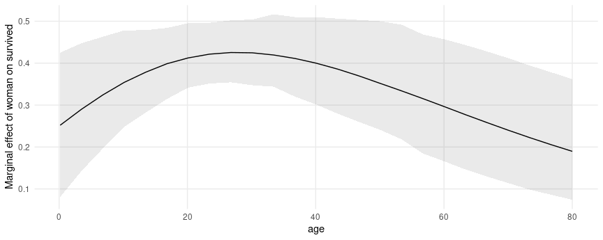

```r
plot_cme(mod, effect = "woman", condition = "age")
```

The `posteriordraws` produces a dataset with `drawid` and `draw` columns:

```r
draws <- posteriordraws(mfx)

dim(draws)
```

```
#> [1] 16736000       10
```

```r
head(draws)
```

```
#>   rowid     type term contrast drawid          draw survived woman age passengerClass
#> 1     1 response  age    dY/dX      1  0.0000882587        1     1  29            1st
#> 2     1 response  age    dY/dX      2  0.0004841800        1     1  29            1st
#> 3     1 response  age    dY/dX      3  0.0002124318        1     1  29            1st
#> 4     1 response  age    dY/dX      4 -0.0007529172        1     1  29            1st
#> 5     1 response  age    dY/dX      5 -0.0007341808        1     1  29            1st
#> 6     1 response  age    dY/dX      6  0.0003494105        1     1  29            1st
```

We can use this dataset to plot our results. For example, to plot the posterior density of the marginal effect of `age` when the `woman` variable is equal to 0 or 1:

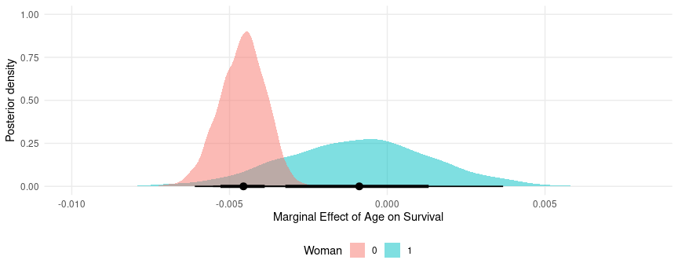

```r
mfx <- marginaleffects(mod,
                       variables = "age",
                       newdata = datagrid(woman = 0:1)) |>
       posteriordraws()

ggplot(mfx, aes(x = draw, fill = factor(woman))) +
    stat_halfeye(slab_alpha = .5) +
    labs(x = "Marginal Effect of Age on Survival",
         y = "Posterior density",
         fill = "Woman")
```

# Random effects model

This section replicates some of the analyses of a random effects model published in Andrew Heiss’ blog post: [“A guide to correctly calculating posterior predictions and average marginal effects with multilievel Bayesian models.”](https://www.andrewheiss.com/blog/2021/11/10/ame-bayes-re-guide) The objective is mainly to illustrate the use of `marginaleffects`. Please refer to the original post for a detailed discussion of the quantities computed below.

Load libraries and download data:

```r
library(brms)
library(ggdist)
library(patchwork)
library(marginaleffects)

vdem_2015 <- read.csv("https://github.com/vincentarelbundock/marginaleffects/raw/main/data-raw/vdem_2015.csv")

head(vdem_2015)
```

```
#>   country_name country_text_id year                           region media_index party_autonomy_ord
#> 1       Mexico             MEX 2015  Latin America and the Caribbean       0.837                  3
#> 2     Suriname             SUR 2015  Latin America and the Caribbean       0.883                  4
#> 3       Sweden             SWE 2015 Western Europe and North America       0.956                  4
#> 4  Switzerland             CHE 2015 Western Europe and North America       0.939                  4
#> 5        Ghana             GHA 2015               Sub-Saharan Africa       0.858                  4
#> 6 South Africa             ZAF 2015               Sub-Saharan Africa       0.898                  4
#>   polyarchy civil_liberties party_autonomy
#> 1     0.631           0.704           TRUE
#> 2     0.777           0.887           TRUE
#> 3     0.915           0.968           TRUE
#> 4     0.901           0.960           TRUE
#> 5     0.724           0.921           TRUE
#> 6     0.752           0.869           TRUE
```

Fit a basic model:

```r
mod <- brm(
  bf(media_index ~ party_autonomy + civil_liberties + (1 | region),
     phi ~ (1 | region)),
  data = vdem_2015,
  family = Beta(),
  control = list(adapt_delta = 0.9))
```

## Posterior predictions

To compute posterior predictions for specific values of the regressors, we use the `newdata` argument and the `datagrid` function. We also use the `type` argument to compute two types of predictions: accounting for residual (observation-level) residual variance (`prediction`) or ignoring it (`response`).

```r
nd = datagrid(model = mod,
              party_autonomy = c(TRUE, FALSE),
              civil_liberties = .5,
              region = "Middle East and North Africa")
p1 <- predictions(mod, type = "response", newdata = nd) %>%
    posteriordraws()
p2 <- predictions(mod, type = "prediction", newdata = nd) %>%
    posteriordraws()
pred <- rbind(p1, p2)
```

Extract posterior draws and plot them:

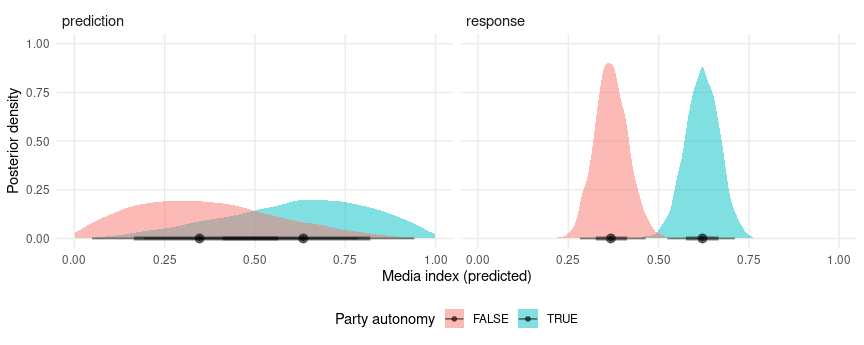

```r
ggplot(pred, aes(x = draw, fill = party_autonomy)) +
    stat_halfeye(alpha = .5) +
    facet_wrap(~ type) +
    labs(x = "Media index (predicted)",
         y = "Posterior density",
         fill = "Party autonomy")
```

## Marginal effects and contrasts

As noted in the [Marginal Effects vignette](https://vincentarelbundock.github.io/marginaleffects/articles/mfx.html), there should be one distinct marginal effect for each combination of regressor values. Here, we consider only one combination of regressor values, where `region` is “Middle East and North Africa”, and `civil_liberties` is 0.5. Then, we calculate the mean of the posterior distribution of marginal effects:

```r
mfx <- marginaleffects(mod,
                       newdata = datagrid(civil_liberties = .5,
                                          region = "Middle East and North Africa"))
mfx
```

```
#>   rowid     type            term     contrast      dydx  conf.low conf.high party_autonomy
#> 1     1 response  party_autonomy TRUE - FALSE 0.2514419 0.1727092 0.3378497           TRUE
#> 2     1 response civil_liberties        dY/dX 0.8161557 0.6245150 1.0072559           TRUE
#>   civil_liberties                       region
#> 1             0.5 Middle East and North Africa
#> 2             0.5 Middle East and North Africa
```

Use the `posteriordraws()` to extract draws from the posterio distribution of marginal effects, and plot them:

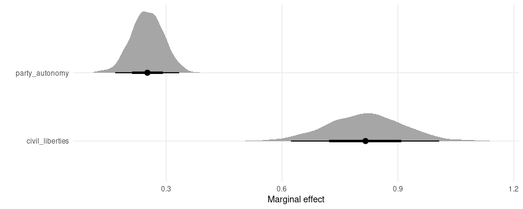

```r
mfx <- posteriordraws(mfx)

ggplot(mfx, aes(x = draw, y = term)) +
  stat_halfeye() +
  labs(x = "Marginal effect", y = "")
```

Plot marginal effects, conditional on a regressor:

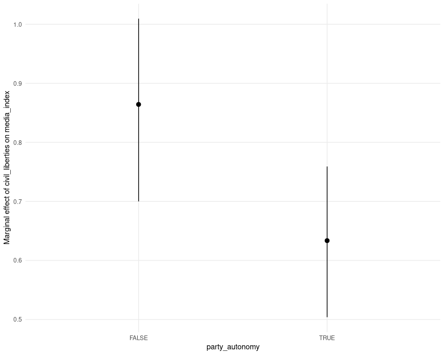

```r
plot_cme(mod,
         effect = "civil_liberties",
         condition = "party_autonomy")
```

## Continuous predictors

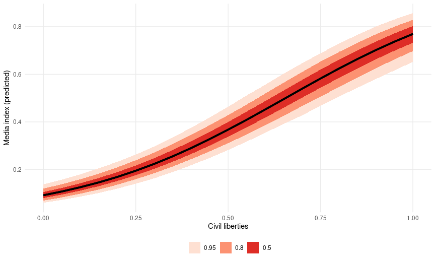

```r
pred <- predictions(mod,
                    newdata = datagrid(party_autonomy = FALSE,
                                       region = "Middle East and North Africa",
                                       civil_liberties = seq(0, 1, by = 0.05))) |>
        posteriordraws()

ggplot(pred, aes(x = civil_liberties, y = draw)) +
    stat_lineribbon() +
    scale_fill_brewer(palette = "Reds") +
    labs(x = "Civil liberties",
         y = "Media index (predicted)",
         fill = "")
```

The slope of this line for different values of civil liberties can be obtained with:

```r
mfx <- marginaleffects(mod,
                       newdata = datagrid(civil_liberties = c(.2, .5, .8),
                                          party_autonomy = FALSE,
                                          region = "Middle East and North Africa"),
                       variables = "civil_liberties")
mfx
```

```
#>   rowid     type            term      dydx  conf.low conf.high civil_liberties party_autonomy
#> 1     1 response civil_liberties 0.4889313 0.3655136 0.6382760             0.2          FALSE
#> 2     2 response civil_liberties 0.8073257 0.6130583 1.0031587             0.5          FALSE
#> 3     3 response civil_liberties 0.8065424 0.6712491 0.9274168             0.8          FALSE
#>                         region
#> 1 Middle East and North Africa
#> 2 Middle East and North Africa
#> 3 Middle East and North Africa
```

And plotted:

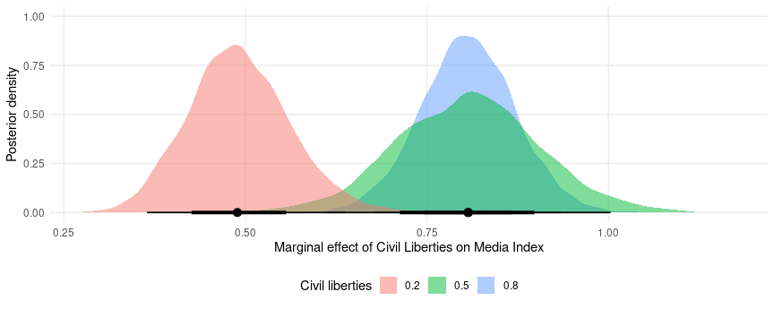

```r
mfx <- posteriordraws(mfx)

ggplot(mfx, aes(x = draw, fill = factor(civil_liberties))) +
    stat_halfeye(slab_alpha = .5) +
    labs(x = "Marginal effect of Civil Liberties on Media Index",
         y = "Posterior density",
         fill = "Civil liberties")
```

The `marginaleffects` function can use the ellipsis (`...`) to push any argument forward to the `posterior_predict` function. This can alter the types of predictions returned. For example, [the `re_formula=NA` argument of the `posterior_predict.brmsfit` method](https://cran.r-project.org/web/packages/brms/brms.pdf) will compute marginaleffects *without* including any group-level effects:

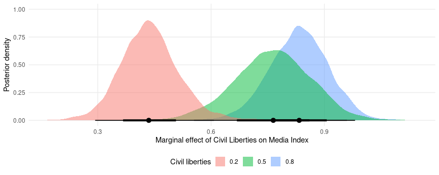

```r
mfx <- marginaleffects(mod,
                       newdata = datagrid(civil_liberties = c(.2, .5, .8),
                                          party_autonomy = FALSE,
                                          region = "Middle East and North Africa"),
                       variables = "civil_liberties",
                       re_formula = NA) |>
       posteriordraws()

ggplot(mfx, aes(x = draw, fill = factor(civil_liberties))) +
    stat_halfeye(slab_alpha = .5) +
    labs(x = "Marginal effect of Civil Liberties on Media Index",
         y = "Posterior density",
         fill = "Civil liberties")
```

## Global grand mean

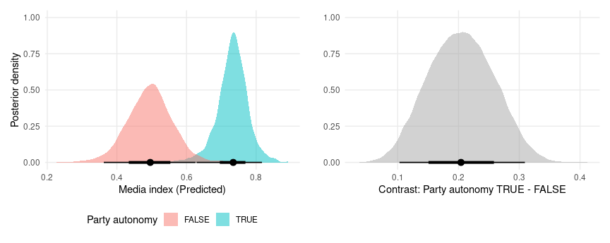

```r
pred <- predictions(mod,
                    re_formula = NA,
                    newdata = datagrid(party_autonomy = c(TRUE, FALSE))) |>
        posteriordraws()

mfx <- marginaleffects(mod,
                       re_formula = NA,
                       variables = "party_autonomy") |>
       posteriordraws()

plot1 <- ggplot(pred, aes(x = draw, fill = party_autonomy)) +
         stat_halfeye(slab_alpha = .5) +
         labs(x = "Media index (Predicted)",
              y = "Posterior density",
              fill = "Party autonomy")

plot2 <- ggplot(mfx, aes(x = draw)) +
         stat_halfeye(slab_alpha = .5)  +
         labs(x = "Contrast: Party autonomy TRUE - FALSE",
              y = "",
              fill = "Party autonomy")

# combine plots using the `patchwork` package
plot1 + plot2
```

## Region-specific predictions and contrasts

Predicted media index by region and level of civil liberties:

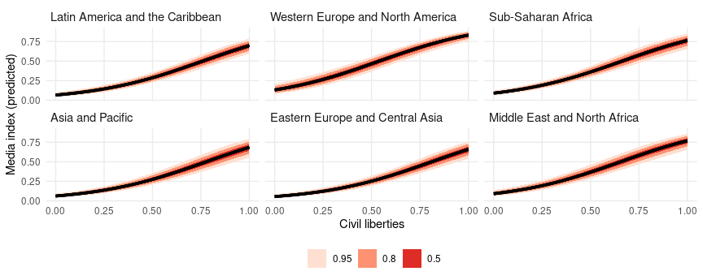

```r
pred <- predictions(mod,
                    newdata = datagrid(region = vdem_2015$region,
                                       party_autonomy = FALSE,
                                       civil_liberties = seq(0, 1, length.out = 100))) |>
        posteriordraws()

ggplot(pred, aes(x = civil_liberties, y = draw)) +
    stat_lineribbon() +
    scale_fill_brewer(palette = "Reds") +
    facet_wrap(~ region) +
    labs(x = "Civil liberties",
         y = "Media index (predicted)",
         fill = "")
```

Predicted media index by region and level of civil liberties:

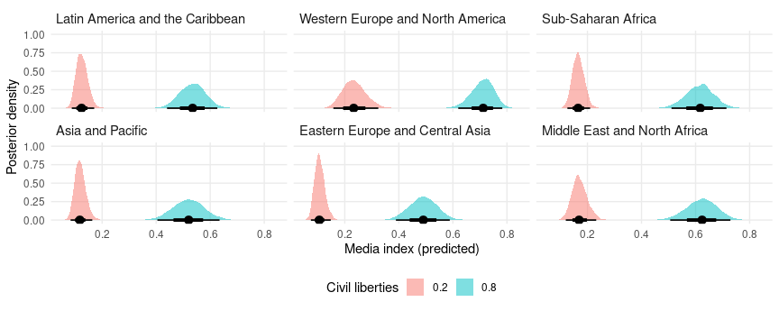

```r
pred <- predictions(mod,
                    newdata = datagrid(region = vdem_2015$region,
                                       civil_liberties = c(.2, .8),
                                      party_autonomy = FALSE)) |>
        posteriordraws()

ggplot(pred, aes(x = draw, fill = factor(civil_liberties))) +
    stat_halfeye(slab_alpha = .5) +
    facet_wrap(~ region) +
    labs(x = "Media index (predicted)",
         y = "Posterior density",
         fill = "Civil liberties")
```

Predicted media index by region and party autonomy:

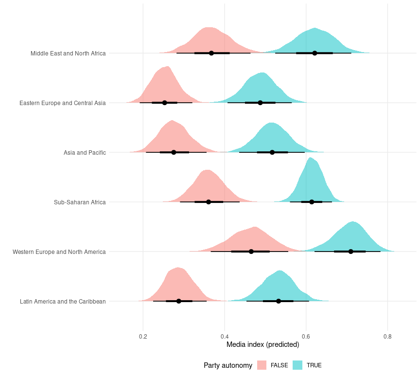

```r
pred <- predictions(mod,
                    newdata = datagrid(region = vdem_2015$region,
                                       party_autonomy = c(TRUE, FALSE),
                                       civil_liberties = .5)) |>
        posteriordraws()

ggplot(pred, aes(x = draw, y = region , fill = party_autonomy)) +
    stat_halfeye(slab_alpha = .5) +
    labs(x = "Media index (predicted)",
         y = "",
         fill = "Party autonomy")
```

TRUE/FALSE contrasts (marginal effects) of party autonomy by region:

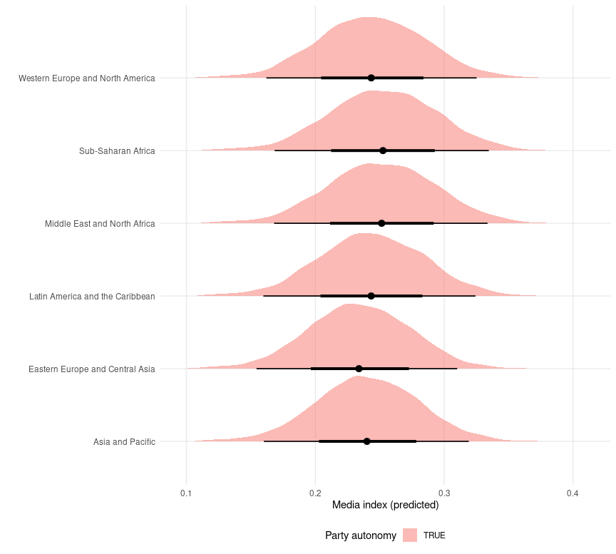

```r
mfx <- marginaleffects(mod,
                       variables = "party_autonomy",
                       newdata = datagrid(region = vdem_2015$region,
                                          civil_liberties = .5)) |>
        posteriordraws()

ggplot(mfx, aes(x = draw, y = region , fill = party_autonomy)) +
    stat_halfeye(slab_alpha = .5) +
    labs(x = "Media index (predicted)",
         y = "",
         fill = "Party autonomy")
```

## Hypothetical groups

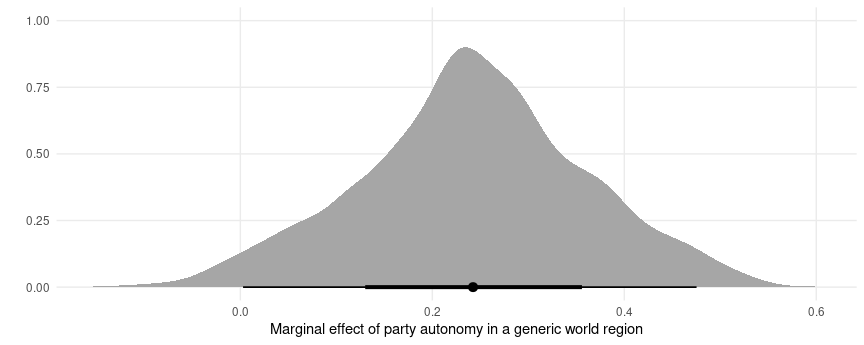

```r
dat <- data.frame(civil_liberties = .5,
                  party_autonomy = FALSE,
                  region = "New Region")

mfx <- marginaleffects(
    mod,
    variables = "party_autonomy",
    allow_new_levels = TRUE,
    newdata = dat)

draws <- posteriordraws(mfx)

ggplot(draws, aes(x = draw)) +
     stat_halfeye() +
     labs(x = "Marginal effect of party autonomy in a generic world region", y = "")
```

# Multinomial logit

Fit a model with categorical outcome (heating system choice in California houses) and logit link:

```r
dat <- "https://vincentarelbundock.github.io/Rdatasets/csv/Ecdat/Heating.csv"
dat <- read.csv(dat)

mod <- brm(depvar ~ ic.gc + oc.gc,
           data = dat,
           family = categorical(link = "logit"))
```

## Adjusted predictions

Compute predicted probabilities for each level of the outcome variable:

```r
pred <- predictions(mod)

head(pred)
```

```
#>   rowid     type group  predicted depvar  ic.gc  oc.gc   conf.low  conf.high
#> 1     1 response    ec 0.06650248     gc 866.00 199.69 0.04444724 0.09105698
#> 2     2 response    ec 0.07698538     gc 727.93 168.66 0.05963308 0.09663204
#> 3     3 response    ec 0.10419361     gc 599.48 165.58 0.06036268 0.15931857
#> 4     4 response    ec 0.06352814     er 835.17 180.88 0.04593506 0.08205828
#> 5     5 response    ec 0.07480561     er 755.59 174.91 0.05786132 0.09305666
#> 6     6 response    ec 0.07151562     gc 666.11 135.67 0.04472428 0.10273280
```

Extract posterior draws and plot them:

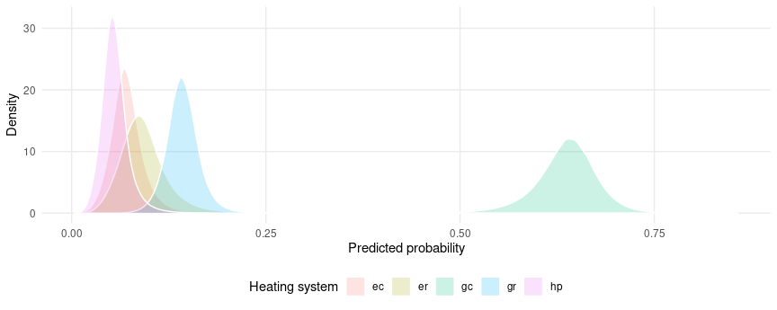

```r
draws <- posteriordraws(pred)

ggplot(draws, aes(x = draw, fill = group)) +
    geom_density(alpha = .2, color = "white") +
    labs(x = "Predicted probability",
         y = "Density",
         fill = "Heating system")
```

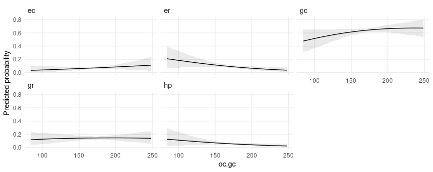

```r
plot_cap(mod, condition = "oc.gc") +
    facet_wrap(~ group) +
    labs(y = "Predicted probability")
```

## Marginal effects

```r
mfx <- marginaleffects(mod)
summary(mfx)
```

```
#> Average marginal effects
#>    Group  Term     Effect      2.5 %    97.5 %
#> 1     ec ic.gc -1.826e-04 -4.093e-04 3.378e-05
#> 2     ec oc.gc  4.875e-04 -4.283e-04 1.476e-03
#> 3     er ic.gc  1.673e-05 -2.130e-04 2.408e-04
#> 4     er oc.gc -1.025e-03 -2.005e-03 1.385e-05
#> 5     gc ic.gc  1.235e-05 -3.674e-04 3.875e-04
#> 6     gc oc.gc  1.057e-03 -5.282e-04 2.791e-03
#> 7     gr ic.gc  4.252e-05 -2.575e-04 3.130e-04
#> 8     gr oc.gc  7.841e-05 -1.191e-03 1.299e-03
#> 9     hp ic.gc  1.110e-04 -6.588e-05 2.983e-04
#> 10    hp oc.gc -5.973e-04 -1.420e-03 2.241e-04
#>
#> Model type:  brmsfit
#> Prediction type:  response
```